# Introduction

This is the EDA notebook, for the genuine challenge 2; Predicting Airbnb prices

### Importing libraries

```python
import numpy as np
import pandas as pd
import matplotlib.pyplot as plt
import seaborn as sns

from sklearn.model_selection import train_test_split
from sklearn.linear_model import LinearRegression
from sklearn.neighbors import KNeighborsClassifier
from sklearn import metrics
```

### Importing data

```python
data1 = pd.read_csv(r'C:\Users\jedrz\Desktop\Fontys\Semester 4\gench2\AB_US_2020.csv', dtype={'host_name':'string'})
data2 = pd.read_csv(r'C:\Users\jedrz\Desktop\Fontys\Semester 4\gench2\listings.csv', dtype={'host_name':'string'})
frames = [data1,data2]
data = pd.concat(frames)
```

### Data Preperation

```python
data.head()
```

|  | id | name | host_id | host_name | neighbourhood_group | neighbourhood | latitude | longitude | room_type | price | minimum_nights | number_of_reviews | last_review | reviews_per_month | calculated_host_listings_count | availability_365 | city |
| --- | --- | --- | --- | --- | --- | --- | --- | --- | --- | --- | --- | --- | --- | --- | --- | --- | --- |
| 0 | 38585 | Charming Victorian home - twin beds + breakfast | 165529 | Evelyne | NaN | 28804 | 35.65146 | -82.62792 | Private room | 60 | 1 | 138 | 16/02/20 | 1.14 | 1 | 0 | Asheville |
| 1 | 80905 | French Chic Loft | 427027 | Celeste | NaN | 28801 | 35.59779 | -82.55540 | Entire home/apt | 470 | 1 | 114 | 07/09/20 | 1.03 | 11 | 288 | Asheville |
| 2 | 108061 | Walk to stores/parks/downtown. Fenced yard/Pet... | 320564 | Lisa | NaN | 28801 | 35.60670 | -82.55563 | Entire home/apt | 75 | 30 | 89 | 30/11/19 | 0.81 | 2 | 298 | Asheville |
| 3 | 155305 | Cottage! BonPaul + Sharky's Hostel | 746673 | BonPaul | NaN | 28806 | 35.57864 | -82.59578 | Entire home/apt | 90 | 1 | 267 | 22/09/20 | 2.39 | 5 | 0 | Asheville |
| 4 | 160594 | Historic Grove Park | 769252 | Elizabeth | NaN | 28801 | 35.61442 | -82.54127 | Private room | 125 | 30 | 58 | 19/10/15 | 0.52 | 1 | 0 | Asheville |

```python
data.describe()
```

|  | id | host_id | latitude | longitude | price | minimum_nights | number_of_reviews | reviews_per_month | calculated_host_listings_count | availability_365 |
| --- | --- | --- | --- | --- | --- | --- | --- | --- | --- | --- |
| count | 2.339370e+05 | 2.339370e+05 | 233937.000000 | 233937.000000 | 233937.000000 | 2.339370e+05 | 233937.000000 | 182577.000000 | 233937.000000 | 233937.000000 |
| mean | 2.540135e+07 | 9.344344e+07 | 34.501856 | -96.221777 | 218.013581 | 4.378448e+02 | 33.773106 | 1.420514 | 17.506683 | 160.984949 |
| std | 1.309300e+07 | 9.776662e+07 | 9.157773 | 45.438246 | 564.182614 | 2.067524e+05 | 62.879267 | 1.674526 | 51.787427 | 140.667887 |
| min | 1.090000e+02 | 2.300000e+01 | 1.243870 | -159.714900 | 0.000000 | 1.000000e+00 | 0.000000 | 0.010000 | 1.000000 | 0.000000 |
| 25% | 1.517989e+07 | 1.427763e+07 | 32.692310 | -118.481830 | 75.000000 | 1.000000e+00 | 1.000000 | 0.230000 | 1.000000 | 0.000000 |
| 50% | 2.585930e+07 | 5.154812e+07 | 36.196590 | -97.746670 | 121.000000 | 2.000000e+00 | 7.000000 | 0.800000 | 2.000000 | 144.000000 |
| 75% | 3.739056e+07 | 1.499718e+08 | 40.720070 | -73.999380 | 200.000000 | 7.000000e+00 | 38.000000 | 2.050000 | 7.000000 | 314.000000 |
| max | 4.556085e+07 | 3.679176e+08 | 47.734620 | 103.973420 | 24999.000000 | 1.000000e+08 | 966.000000 | 44.060000 | 593.000000 | 365.000000 |

```python
data.info()
```

```
<class 'pandas.core.frame.DataFrame'>
Int64Index: 233937 entries, 0 to 7906
Data columns (total 17 columns):
 #   Column                          Non-Null Count   Dtype
---  ------                          --------------   -----
 0   id                              233937 non-null  int64
 1   name                            233907 non-null  object
 2   host_id                         233937 non-null  int64
 3   host_name                       233904 non-null  string
 4   neighbourhood_group             118092 non-null  object
 5   neighbourhood                   233937 non-null  object
 6   latitude                        233937 non-null  float64
 7   longitude                       233937 non-null  float64
 8   room_type                       233937 non-null  object
 9   price                           233937 non-null  int64
 10  minimum_nights                  233937 non-null  int64
 11  number_of_reviews               233937 non-null  int64
 12  last_review                     182577 non-null  object
 13  reviews_per_month               182577 non-null  float64
 14  calculated_host_listings_count  233937 non-null  int64
 15  availability_365                233937 non-null  int64
 16  city                            226030 non-null  object
dtypes: float64(3), int64(7), object(6), string(1)
memory usage: 32.1+ MB
```

We can see that the data has 17 columns and 233937 rows. Some of them have null values like 'neighbourhood_group', 'last review' and more. I will take a closer look and see how many missing values we have for these columns.

```python
data.isna().sum()
```

```
id                                     0
name                                  30
host_id                                0
host_name                             33
neighbourhood_group               115845
neighbourhood                          0
latitude                               0
longitude                              0
room_type                              0
price                                  0
minimum_nights                         0
number_of_reviews                      0
last_review                        51360
reviews_per_month                  51360
calculated_host_listings_count         0
availability_365                       0
city                                7907
dtype: int64
```

We can drop the 'id','name', 'last_review', 'host_id', 'host_name' columns, as they have no effect on the prediction

```python
data = data.drop(['name','id','last_review','host_id','host_name','neighbourhood'], axis=1)
```

Now let's take care of the 'reviews_per_month' and 'neighbourhood_group' column, we will replace the missing values with '0' for the reviews and 'none' for the neighbourhood group, and 'Unknown' for the city column

```python
data[['reviews_per_month']] = data[['reviews_per_month']].fillna(value=0)
data[['neighbourhood_group']] = data[['neighbourhood_group']].fillna(value='none')
data[['city']] = data[['city']].fillna(value='Unknown')
```

```python
data.info()
```

```
<class 'pandas.core.frame.DataFrame'>
Int64Index: 233937 entries, 0 to 7906
Data columns (total 11 columns):
 #   Column                          Non-Null Count   Dtype
---  ------                          --------------   -----
 0   neighbourhood_group             233937 non-null  object
 1   latitude                        233937 non-null  float64
 2   longitude                       233937 non-null  float64
 3   room_type                       233937 non-null  object
 4   price                           233937 non-null  int64
 5   minimum_nights                  233937 non-null  int64
 6   number_of_reviews               233937 non-null  int64
 7   reviews_per_month               233937 non-null  float64
 8   calculated_host_listings_count  233937 non-null  int64
 9   availability_365                233937 non-null  int64
 10  city                            233937 non-null  object
dtypes: float64(3), int64(5), object(3)
memory usage: 21.4+ MB
```

Now that we've taken care of the missing values, we can continue onto the EDA.

## EDA

### Numeric features

```python
numeric_features = data.select_dtypes(include=['int64','float64']).columns
```

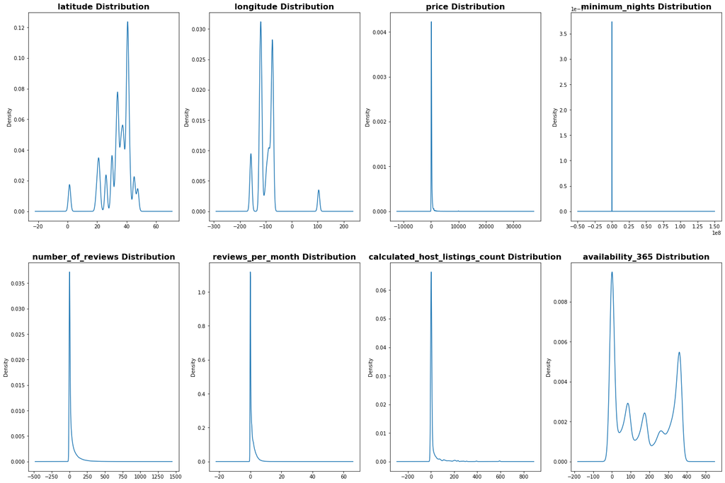

```python
fig, axes = plt.subplots(nrows=2, ncols=4)
aux = 0
fig.set_figheight(17)
fig.set_figwidth(25)
for row in axes:
    for col in row:
        data[numeric_features[aux]].plot(kind='kde',ax=col)
        col.set_title(numeric_features[aux] +' Distribution',fontsize=16,fontweight='bold')
        aux+=1
```

These graphs give some information about the distribution of the numerical values in the dataset, however most of them dont show much information. Let's try removing outliers to get a better idea of the distribution of data.

```python
lower_bound = .25
upper_bound = .75
iqr = data[data['price'].between(data['price'].quantile(lower_bound), data['price'].quantile(upper_bound), inclusive=True)]
iqr = iqr[iqr['number_of_reviews'] > 0]
iqr = iqr[iqr['calculated_host_listings_count'] < 10]
iqr = iqr[iqr['number_of_reviews'] < 200]
iqr = iqr[iqr['minimum_nights'] < 10]
iqr = iqr[iqr['reviews_per_month'] < 5]
```

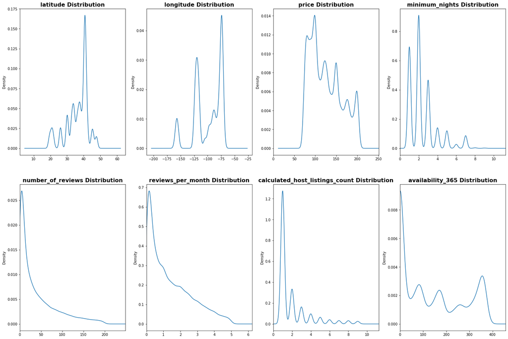

```python
fig, axes = plt.subplots(nrows=2, ncols=4)
aux = 0
fig.set_figheight(17)
fig.set_figwidth(25)
for row in axes:
    for col in row:
        iqr[numeric_features[aux]].plot(kind='kde',ax=col)
        if numeric_features[aux] not in ['latitude','longitude']:
            col.set_xlim(0,iqr[numeric_features[aux]].max()+iqr[numeric_features[aux]].max()*0.25)
        col.set_title(numeric_features[aux] +' Distribution',fontsize=16,fontweight='bold')
        aux+=1
```

After removing outliers, we can see that the graphs provide much more information. For example we can see that the columns 'numer_of_reviews' and 'reviews_per_month' follow an exponential distribution while all other numerical features follow a multimodal distribution, which makes sense since there are underlying groups in the dataset.

Let's also remove the outliers from the price column, as most of the listings have a price range of 40-200. We remove these listings for better predictions.

```python
data=data[(data['price']<200) & (data['price']>40)]
len(data)
```

```
157291
```

After removing the price outliers, we still have enough data in order to train the model

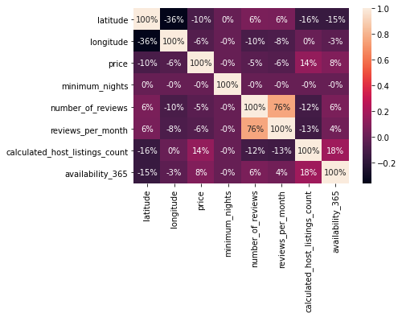

```python
sns.heatmap(data.corr(), annot=True, fmt='.0%')
```

We can see from the heat map that price isn't strongly correlated with any numerical values, with 'calculated_host_listings_count' column having the strongest correlation of 14%. This is dissapointing since all numerical values have a weak correlation, we must choose carefully which features we choose to train the model.

### Categorical features

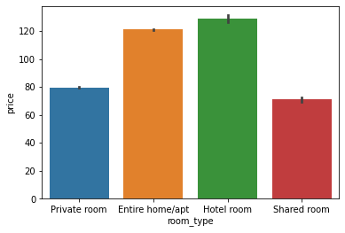

```python
sns.barplot(x=data['room_type'], y=data['price'])
```

We can see that the room type feature has an impact on the price, as both hotel rooms and entire home/apt listing have a much higher price compared to a private and shared room.

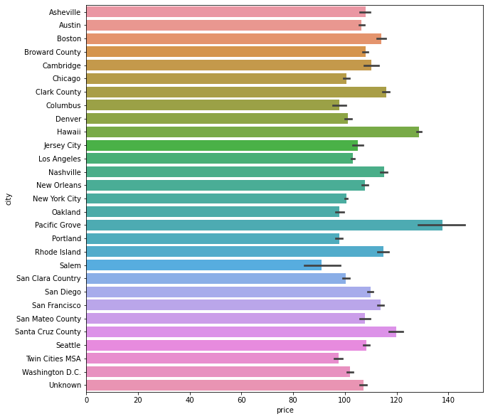

```python
fig_dims = (10, 10)
fig, ax = plt.subplots(figsize=fig_dims)
sns.barplot(x=data['price'], y=data['city'])
```

We can see that the city also has an impact on the price, with the most expensive listings being in Pacific Grove

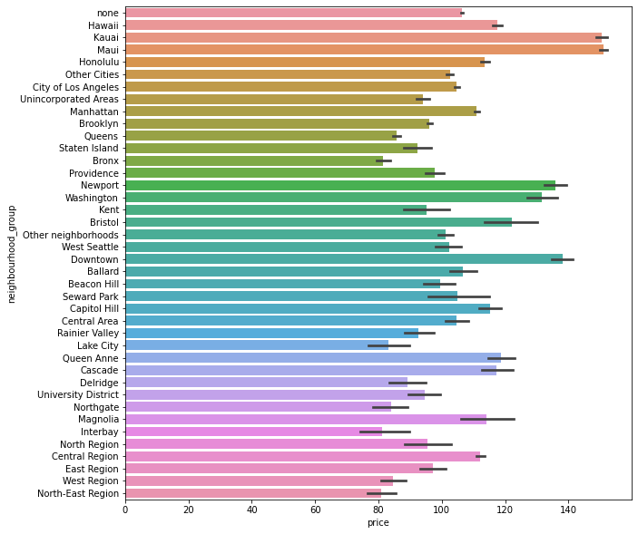

```python
fig_dims = (10, 10)
fig, ax = plt.subplots(figsize=fig_dims)
sns.barplot(x=data.price, y=data['neighbourhood_group'])
```

## Modeling

#### Preproccessing

```python
import sklearn.metrics as sm
from sklearn.preprocessing import LabelEncoder
labelencoder = LabelEncoder()# Assigning numerical values and storing in another column
data['room_type_Cat'] = labelencoder.fit_transform(data['room_type'])
data['city_Cat'] = labelencoder.fit_transform(data['city'])
data['neighbourhood_group_Cat'] = labelencoder.fit_transform(data['neighbourhood_group'])
```

#### Splitting data into x and y

```python
x = data.drop(['price','neighbourhood_group','room_type','city'], axis=1)
y = data.price
```

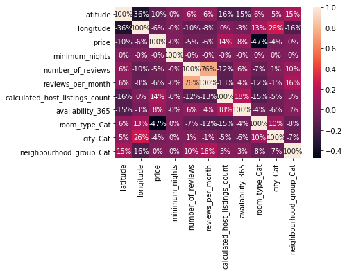

```python
sns.heatmap(data.corr(), annot=True, fmt='.0%')
```

#### Spliting data into train and test sets

```python
x_train, x_test, y_train, y_test = train_test_split(x, y, test_size=0.33, random_state=42)
```

```python
reg = LinearRegression()
reg.fit(x_train, y_train)
y_pred = reg.predict(x_test)
```

```python
results= pd.DataFrame({'Actual': y_test, 'Predicted': y_pred})
results
```

|  | Actual | Predicted |
| --- | --- | --- |
| 177907 | 75 | 96.127915 |
| 177277 | 120 | 117.001929 |
| 48365 | 95 | 129.988674 |
| 154422 | 55 | 71.149828 |
| 151579 | 120 | 79.836737 |
| ... | ... | ... |
| 211202 | 79 | 119.314370 |
| 168592 | 85 | 111.597372 |
| 84470 | 110 | 121.628411 |
| 47515 | 185 | 120.180765 |
| 11816 | 140 | 118.073127 |

51907 rows × 2 columns

```python
mse = sm.mean_squared_error(y_test, y_pred)
print("MSE:", mse)
r2 = sm.r2_score(y_test, y_pred)
print("R2:", r2)
```

```
MSE: 1344.2020895562844
R2: 0.241695729710258
```

the r2 score is the proportion of the variance in the dependent variable that is predictable from the independent variable(s) The mean squared error of a model is the mean of the squared prediction errors over all instances in the test set.

These are the 2 most important metrics for evaluating this model.

These scores make sense due to the low correlation of your features.

#### Feature Selection

```python
x = data.drop(['price','latitude','longitude','minimum_nights','number_of_reviews','calculated_host_listings_count' ,'availability_365','room_type','city','neighbourhood_group'], axis = 1)
y = data.price
```

```python
x.head()
```

|  | reviews_per_month | room_type_Cat | city_Cat | neighbourhood_group_Cat |
| --- | --- | --- | --- | --- |
| 0 | 1.14 | 2 | 0 | 39 |
| 2 | 0.81 | 0 | 0 | 39 |
| 3 | 2.39 | 0 | 0 | 39 |
| 4 | 0.52 | 2 | 0 | 39 |
| 5 | 0.49 | 0 | 0 | 39 |

```python
x_train, x_test, y_train, y_test = train_test_split(x, y, test_size=0.33, random_state=42)
```

```python
reg = LinearRegression()
reg.fit(x_train, y_train)
y_pred = reg.predict(x_test)
```

```python
results= pd.DataFrame({'Actual': y_test, 'Predicted': y_pred})
results
```

|  | Actual | Predicted |
| --- | --- | --- |
| 177907 | 75 | 96.544730 |
| 177277 | 120 | 115.208894 |
| 48365 | 95 | 121.842825 |
| 154422 | 55 | 75.505904 |
| 151579 | 120 | 83.255570 |
| ... | ... | ... |
| 211202 | 79 | 122.176701 |
| 168592 | 85 | 116.255703 |
| 84470 | 110 | 124.186019 |
| 47515 | 185 | 124.033720 |
| 11816 | 140 | 121.279139 |

51907 rows × 2 columns

```python
mse = sm.mean_squared_error(y_test, y_pred)
print("MSE:", mse)
r2 = sm.r2_score(y_test, y_pred)
print("R2:", r2)
```

```
MSE: 1361.2337185337465
R2: 0.2320876826138104
```

This only seems to make the model worse as, both the mean squared error and the r2 score are worse. However we can see that most actual and predicted vales are in a similar price range. I will group the prices into groups in order to try improve the model.

### K-nearest neighbours (KNN)

```python
price_cat_limits = [
    (data['price'] <= 50),
    (data['price'] > 50) & (data['price'] <=75),
    (data['price'] >75) & (data['price'] <= 100),
    (data['price'] >100) & (data['price'] <= 150),
    (data['price'] >150) & (data['price'] <= 200)
]
price_cat = ['<50','50-75','75-100','100-150','150-200']
data['price_range'] = np.select(price_cat_limits,price_cat)
```

```python
data['price_range'].value_counts()
```

```
100-150    47391
75-100     37945
50-75      32649
150-200    25932
<50        13374
Name: price_range, dtype: int64
```

```python
data['price_range_cat'] = labelencoder.fit_transform(data['price_range'])
```

```python
x = data.drop(['price','neighbourhood_group','room_type','city','price_range'], axis=1)
y = data.price_range_cat
```

#### Test train split

```python
x_train, x_test, y_train, y_test = train_test_split(x, y, test_size=0.33, random_state=42)
```

#### Standardize data

```python
from sklearn.preprocessing import StandardScaler
scaler = StandardScaler()
scaler.fit(x_train)
x_train = scaler.transform(x_train)
x_test = scaler.transform(x_test)
```

#### Training

```python
knn = KNeighborsClassifier(n_neighbors=3)
knn.fit(x_train,y_train)
```

```
KNeighborsClassifier(n_neighbors=3)
```

```python
y_predknn=knn.predict(x_test)
```

```python
results= pd.DataFrame({'Actual': y_test, 'Predicted': y_predknn})
results
```

|  | Actual | Predicted |
| --- | --- | --- |
| 177907 | 2 | 3 |
| 177277 | 0 | 0 |
| 48365 | 3 | 3 |
| 154422 | 2 | 2 |
| 151579 | 0 | 0 |
| ... | ... | ... |
| 211202 | 3 | 3 |
| 168592 | 3 | 3 |
| 84470 | 0 | 0 |
| 47515 | 1 | 1 |
| 11816 | 0 | 0 |

51907 rows × 2 columns

```python
print(knn.score(x_test,y_test))
```

```
0.9892885352649932
```